# Analysis for WSN abstract

M Fisher

2022-10-11

# Description

Summarize the following from the sequencing run:

1. Prey diversity:
1. alpha diversity - what proportion of reads were identified down to genus or species? overall and per crab
2. beta diversity - What was the unique number of taxa identified per site/month? per site?
3. taxonomic distinctness (vegan doc)[https://search.r-project.org/CRAN/refmans/vegan/html/taxondive.html]
4. nMDS
2. Prey identification:
1. what proportion of crab from each site had eaten a given phylum / class?
2. what proportion of crab from each site had eaten a given group of species, based on common names?

For this analysis, I removed any identifications that with too little taxonomic depth (information at family or below is missing.

What are the final sample sizes for this data set?

```
## # A tibble: 4 x 2
##   Site      `Crab count`
##   <chr>            <int>
## 1 CLAY                10
## 2 KAY                 11
## 3 KAY-shell            6
## 4 MARPT                2
```

And let’s check the number of crab / site with 1,2 and 3 replicates retained.

```
##            nreps
## Site         2  3
##   CLAY       0 10
##   KAY        1 10
##   KAY-shell  0  6
##   MARPT      0  2
```

Good, most crab have all three replicates retained after filtering.

I’m interested in two versions of the final filtered data set: one including only species-level taxonomy (**species**), and one including taxa that are unique to a given site (**unique taxa**). For example, if a taxon is only identified down to genus, and that genus is found in another ID at the same site, it will be removed; but if it is not found in another ID at the same site, it is retained. I’ll save this as a separate dataset.

```r
write_csv(taxa.dat, (here(indir, 'lerayXT_r1_sample_taxonomy_filtered_SiteUniqueTaxa.csv')))
```

And I’ll save a list of the species / taxa to look up common names:

[output not shown]

```r
write_csv(taxa_list, here('data','results','lerayXT_r1_taxa_common_names.csv'))
write_csv(species_list, here('data','results','lerayXT_r1_species_common_names.csv'))
```

# Prey Diversity

### Alpha div

What is the species richness ($\alpha$ diversity) at each site, for **species?** Richness per crab is simply the species richness / total crab from site.

```
## [1] 100
```

```
## # A tibble: 4 x 4
##   Site      ncrab species.richness mean.richness.per.crab
##   <chr>     <int>            <int>                  <dbl>
## 1 CLAY         10               50                   5
## 2 KAY          11               50                   4.55
## 3 KAY-shell     6               30                   5
## 4 MARPT         2               14                   7
```

What is the $\alpha$ diversity at each site, for unique taxa?

```
## [1] 142
```

```
## # A tibble: 4 x 4
##   Site      ncrab taxa.richness mean.richness.per.crab
##   <chr>     <int>         <int>                  <dbl>
## 1 CLAY         10            71                   7.1
## 2 KAY          11            64                   5.82
## 3 KAY-shell     6            43                   7.17
## 4 MARPT         2            21                  10.5
```

### Beta div

What is the $\beta$ diversity for species? (the ratio between regional and local species diversity)

```
##           1         2         3
## 2 0.5365854
## 3 0.6862745 0.6829268
## 4 0.8484848 0.9130435 0.7575758
```

```
## [1] "KAY"       "KAY-shell" "CLAY"      "MARPT"
```

The greater the similarity in community composition between multiple communities, the lower the value of β-diversity for that set of communities.

Beta diversity is greater between distant sites (Kayak Point v. Clayton Beach v. March Point) than it is between neighboring sites (Kayak Point eelgrass v. shell).

What is the $\beta$ diversity for taxa?

```
##           1         2         3
## 2 0.5596330
## 3 0.7518248 0.7068966
## 4 0.8160920 0.8484848 0.8085106
```

```
## [1] "KAY"       "KAY-shell" "CLAY"      "MARPT"
```

The same pattern holds as above.

### nMDS

**For Species**

```
## *** Solution reached
```

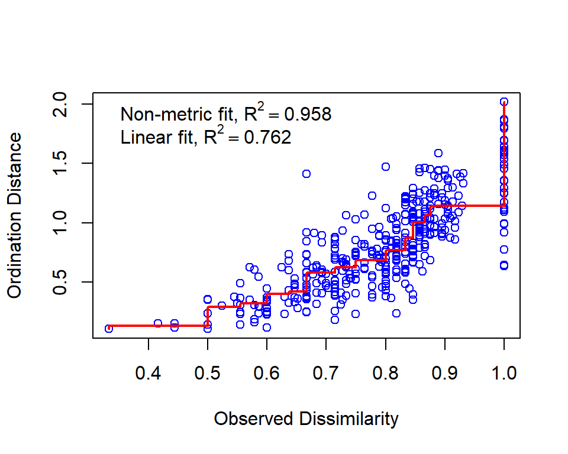

Disclaimer that **the stress is at 0.2, which is potentially misleading**.

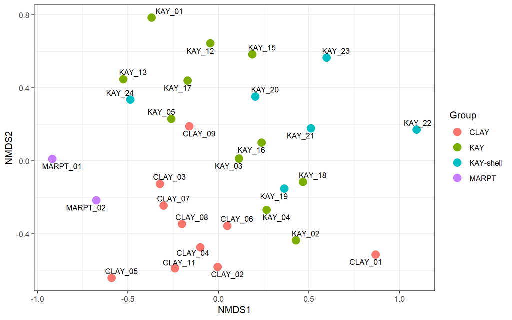

lol what a mess.

## Saturation

### Overall

How many unique species are added per new crab?

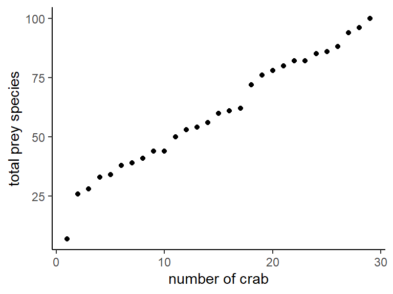

At higher taxonomic levels:

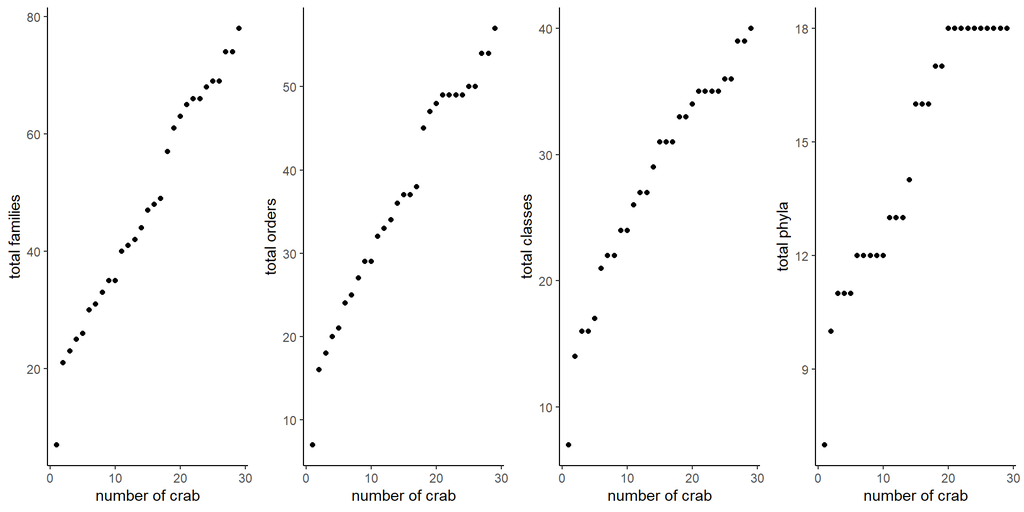

### By site

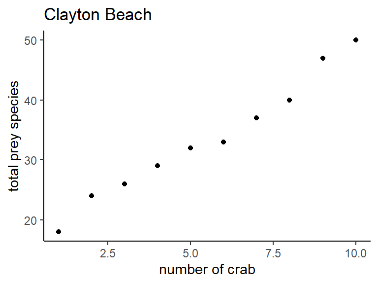

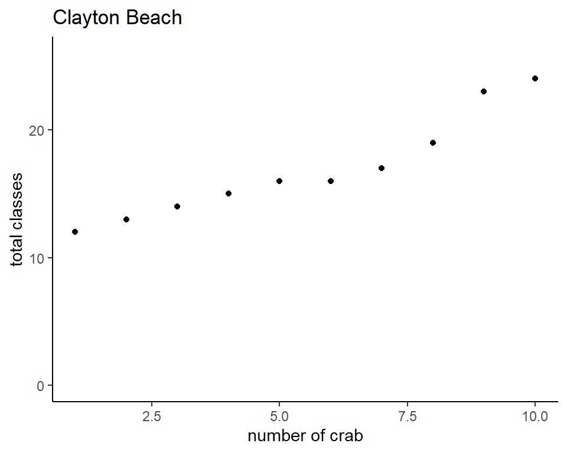

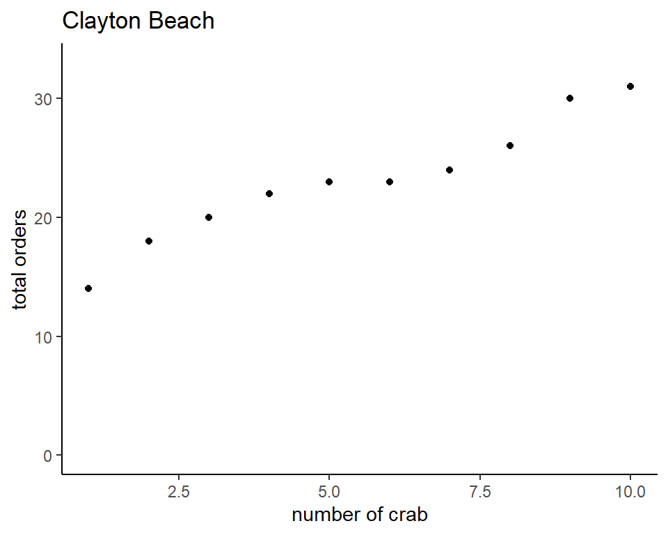

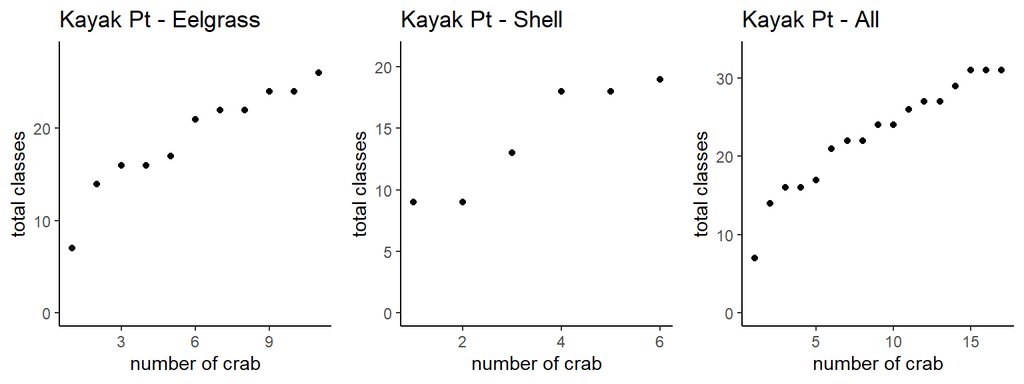

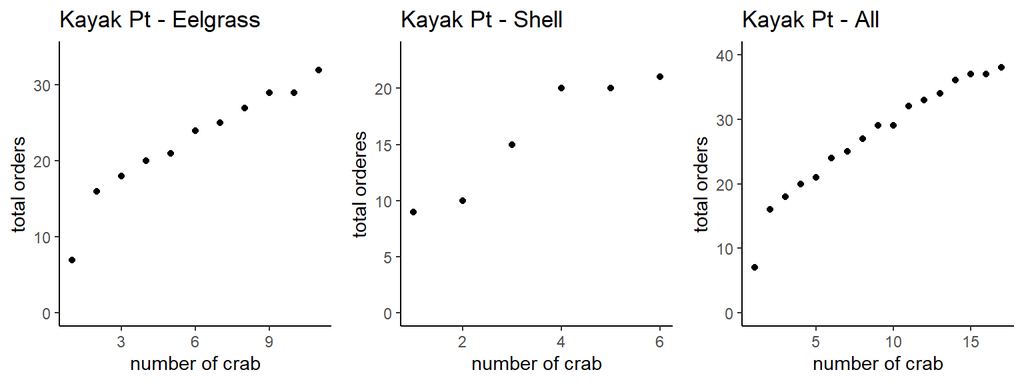

# Prey Identification

```r
taxa_summary <- read_csv(here('data','results','lerayXT_r1_species_filtered_common_names.csv'))
```

## Overall

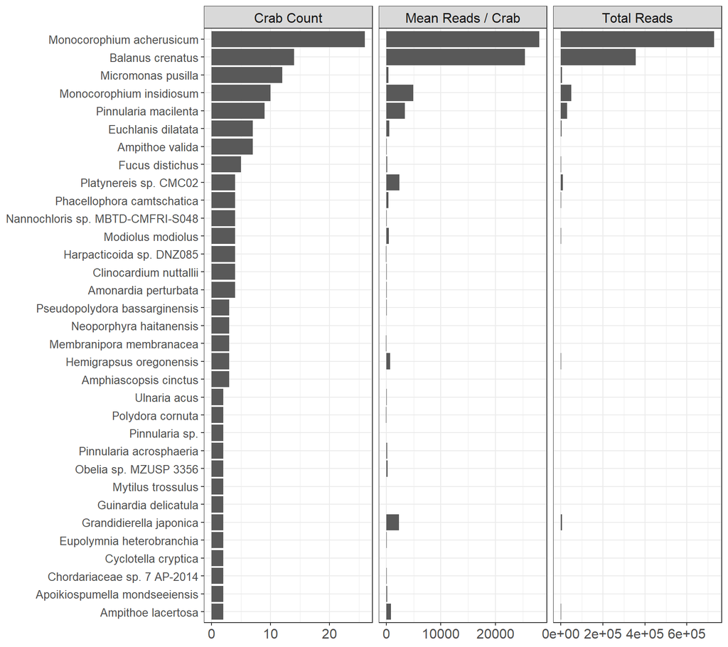

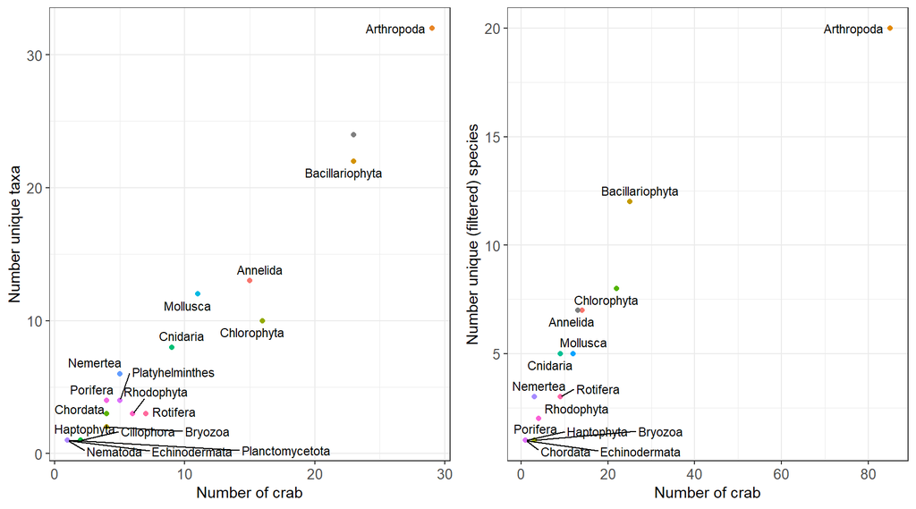

## By site

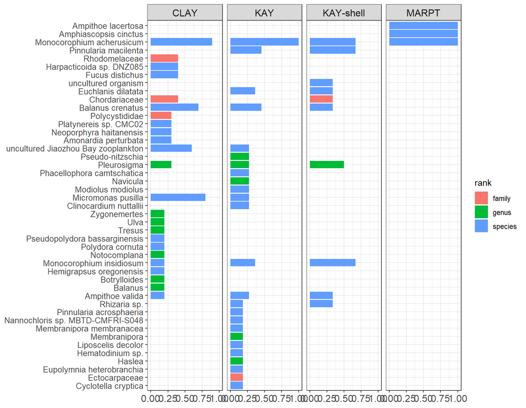

save this summary

```r
write_csv(taxa_summary_bysite,here(indir, 'lerayXT_r1_taxonomy_summary_by_site.csv'))
```

What about at higher orders of taxonomy? For only those identifications to species.

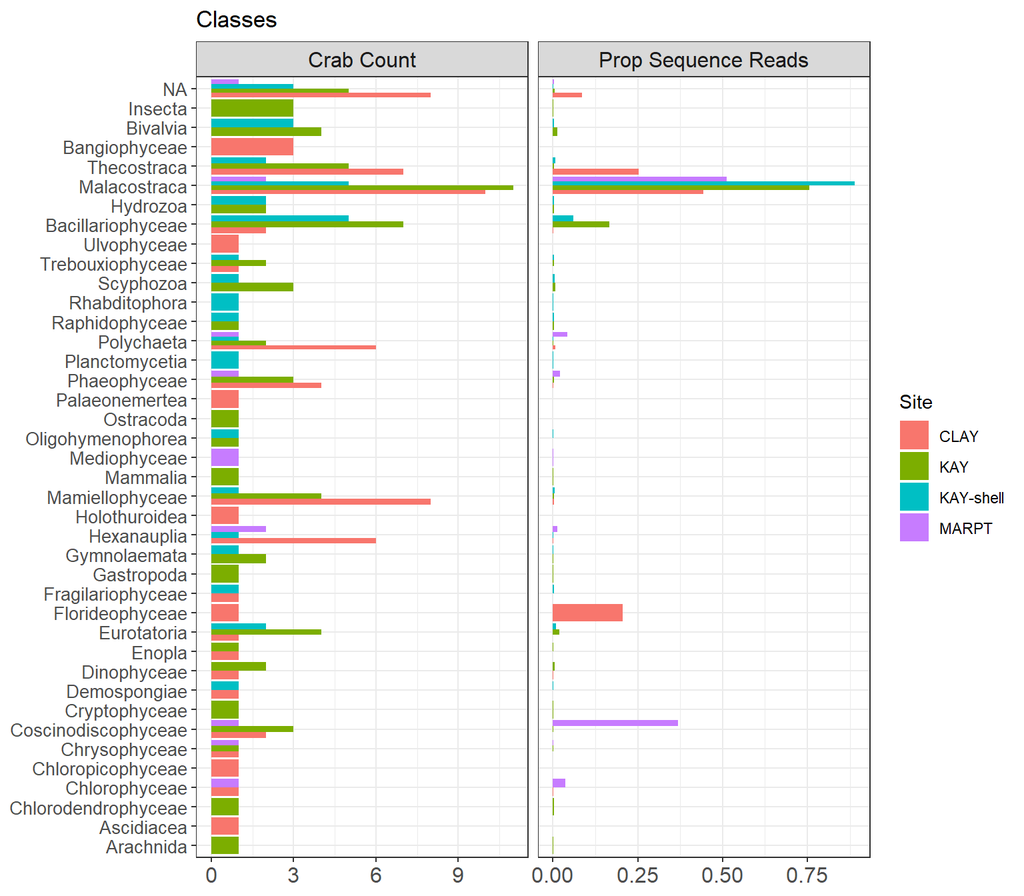

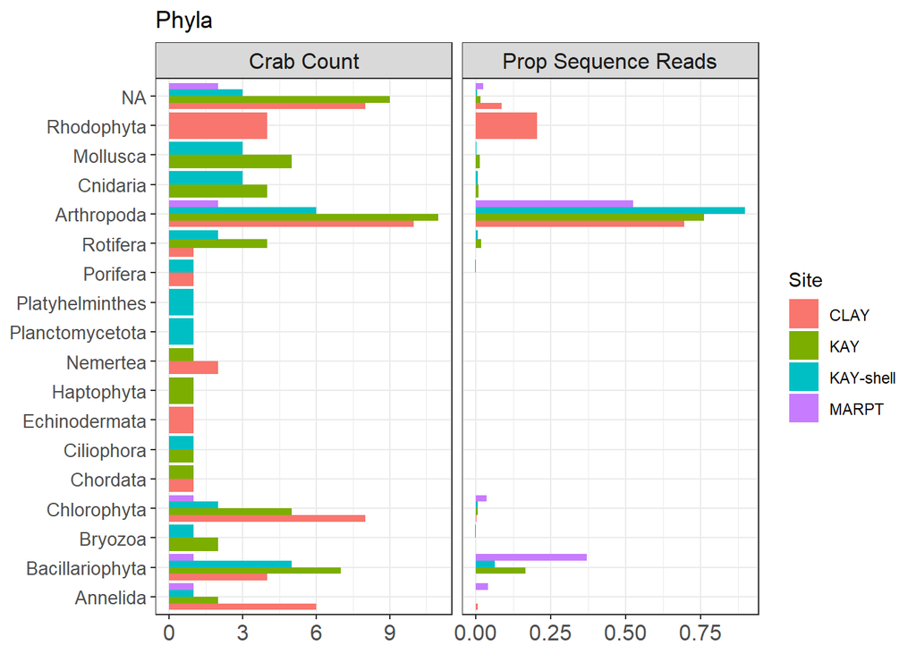

What’s going on with the “NA” phylum?

```
##  [1] "Chordariaceae sp. 7 AP-2014"         "Chordariaceae"
##  [3] "Petalonia fascia"                    "Scytosiphon sp. Mitopromiscuus"
##  [5] "Scytosiphon"                         "invertebrate environmental sample"
##  [7] "uncultured Jiaozhou Bay zooplankton" "Rhizaria sp."
##  [9] "Hormosira banksii"                   "Ectocarpaceae"
## [11] "Guillardia theta"                    "Hematodinium sp."
## [13] "Apoikiospumella mondseeiensis"       "Chattonella marina"
## [15] "uncultured organism"                 "Heterosigma akashiwo"
## [17] "Fucus distichus"                     "Ectocarpus crouaniorum"
## [19] "Ralfsiaceae"                         "Hincksia"
## [21] "Paraphysomonas sp."                  "Sargassum"
## [23] "Acinetosporaceae"                    "Saccharina"
```

Some larger algae, some single-celled algae.